# US Flights Analysis: Jan - Apr 2008

## by Pride Chamisa

- Introduction
- Preliminary Wrangling
- Univariate Exploration
- Bivariate Exploration
- Multivariate Exploration
- Conclusions

## Introduction

> This analysis explores flight data that includes arrival and departure details, carriers, arrival and departure delays, reasons for delays, etc, for all commercial flights within the USA, from January to April 2008. This database contains scheduled and actual departure and arrival times reported by certified U.S. air carriers that account for at least one percent of domestic scheduled passenger revenues. The data is collected by the Office of Airline Information, Bureau of Transportation Statistics (BTS).The data consists of 2389217 records in total and the datasets are available for download from: https://dataverse.harvard.edu/dataset.xhtml?persistentId=doi:10.7910/DVN/HG7NV7

## Preliminary Wrangling

```python
# import all packages and set plots to be embedded inline
import numpy as np
import pandas as pd
import matplotlib.pyplot as plt
import seaborn as sb
import warnings

warnings.filterwarnings("ignore")
%matplotlib inline
```

```python
# Load and display the variable descriptions
descriptions = pd.read_csv('datasets/variable-descriptions.csv', header=2)
descriptions
```

|  | Unnamed: 0 | Name | Description |
| --- | --- | --- | --- |
| 0 | 1 | Year | 1987-2008 |
| 1 | 2 | Month | 12-Jan |
| 2 | 3 | DayofMonth | 31-Jan |
| 3 | 4 | DayOfWeek | 1 (Monday) - 7 (Sunday) |
| 4 | 5 | DepTime | actual departure time (local, hhmm) |
| 5 | 6 | CRSDepTime | scheduled departure time (local, hhmm) |
| 6 | 7 | ArrTime | actual arrival time (local, hhmm) |
| 7 | 8 | CRSArrTime | scheduled arrival time (local, hhmm) |
| 8 | 9 | UniqueCarrier | unique carrier code |
| 9 | 10 | FlightNum | flight number |
| 10 | 11 | TailNum | plane tail number |
| 11 | 12 | ActualElapsedTime | in minutes |
| 12 | 13 | CRSElapsedTime | in minutes |
| 13 | 14 | AirTime | in minutes |
| 14 | 15 | ArrDelay | arrival delay, in minutes |
| 15 | 16 | DepDelay | departure delay, in minutes |
| 16 | 17 | Origin | origin IATA airport code |
| 17 | 18 | Dest | destination IATA airport code |
| 18 | 19 | Distance | in miles |
| 19 | 20 | TaxiIn | taxi in time, in minutes |
| 20 | 21 | TaxiOut | taxi out time in minutes |
| 21 | 22 | Cancelled | was the flight cancelled? |
| 22 | 23 | CancellationCode | reason for cancellation (A = carrier, B = weat... |
| 23 | 24 | Diverted | 1 = yes, 0 = no |
| 24 | 25 | CarrierDelay | in minutes |
| 25 | 26 | WeatherDelay | in minutes |
| 26 | 27 | NASDelay | in minutes |
| 27 | 28 | SecurityDelay | in minutes |
| 28 | 29 | LateAircraftDelay | in minutes |

```python
descriptions.rename(columns={'Unnamed: 0': 'index'}, inplace=True)
```

```python
descriptions.head(3)
```

|  | index | Name | Description |
| --- | --- | --- | --- |
| 0 | 1 | Year | 1987-2008 |
| 1 | 2 | Month | 12-Jan |
| 2 | 3 | DayofMonth | 31-Jan |

```python
# Information about individual planes
planes = pd.read_csv('datasets/plane-data.csv')
planes.sample(5)
```

|  | tailnum | type | manufacturer | issue_date | model | status | aircraft_type | engine_type | year |
| --- | --- | --- | --- | --- | --- | --- | --- | --- | --- |
| 2550 | N583HA | Corporation | BOEING | 03/04/2002 | 767-33A | Valid | Fixed Wing Multi-Engine | Turbo-Fan | None |
| 2041 | N491UA | Corporation | AIRBUS | 04/11/2002 | A320-232 | Valid | Fixed Wing Multi-Engine | Turbo-Fan | 2002 |
| 4150 | N838MH | Corporation | BOEING | 01/12/2001 | 767-432ER | Valid | Fixed Wing Multi-Engine | Turbo-Jet | 2001 |
| 566 | N187DN | Corporation | BOEING | 06/20/1996 | 767-332 | Valid | Fixed Wing Multi-Engine | Turbo-Fan | 1996 |
| 1514 | N391AA | Corporation | BOEING | 02/17/1995 | 767-323 | Valid | Fixed Wing Multi-Engine | Turbo-Fan | 1995 |

```python
# loading the main dataset
df_2008 = pd.read_csv('datasets/2008.csv')
df_2008.head(10)
```

|  | Year | Month | DayofMonth | DayOfWeek | DepTime | CRSDepTime | ArrTime | CRSArrTime | UniqueCarrier | FlightNum | ... | TaxiIn | TaxiOut | Cancelled | CancellationCode | Diverted | CarrierDelay | WeatherDelay | NASDelay | SecurityDelay | LateAircraftDelay |
| --- | --- | --- | --- | --- | --- | --- | --- | --- | --- | --- | --- | --- | --- | --- | --- | --- | --- | --- | --- | --- | --- |
| 0 | 2008 | 1 | 3 | 4 | 1343.0 | 1325 | 1451.0 | 1435 | WN | 588 | ... | 4.0 | 9.0 | 0 | NaN | 0 | 16.0 | 0.0 | 0.0 | 0.0 | 0.0 |
| 1 | 2008 | 1 | 3 | 4 | 1125.0 | 1120 | 1247.0 | 1245 | WN | 1343 | ... | 3.0 | 8.0 | 0 | NaN | 0 | NaN | NaN | NaN | NaN | NaN |
| 2 | 2008 | 1 | 3 | 4 | 2009.0 | 2015 | 2136.0 | 2140 | WN | 3841 | ... | 2.0 | 14.0 | 0 | NaN | 0 | NaN | NaN | NaN | NaN | NaN |
| 3 | 2008 | 1 | 3 | 4 | 903.0 | 855 | 1203.0 | 1205 | WN | 3 | ... | 5.0 | 7.0 | 0 | NaN | 0 | NaN | NaN | NaN | NaN | NaN |
| 4 | 2008 | 1 | 3 | 4 | 1423.0 | 1400 | 1726.0 | 1710 | WN | 25 | ... | 6.0 | 10.0 | 0 | NaN | 0 | 16.0 | 0.0 | 0.0 | 0.0 | 0.0 |
| 5 | 2008 | 1 | 3 | 4 | 2024.0 | 2020 | 2325.0 | 2325 | WN | 51 | ... | 13.0 | 7.0 | 0 | NaN | 0 | NaN | NaN | NaN | NaN | NaN |
| 6 | 2008 | 1 | 3 | 4 | 1753.0 | 1745 | 2053.0 | 2050 | WN | 940 | ... | 6.0 | 7.0 | 0 | NaN | 0 | NaN | NaN | NaN | NaN | NaN |
| 7 | 2008 | 1 | 3 | 4 | 622.0 | 620 | 935.0 | 930 | WN | 2621 | ... | 7.0 | 19.0 | 0 | NaN | 0 | NaN | NaN | NaN | NaN | NaN |
| 8 | 2008 | 1 | 3 | 4 | 1944.0 | 1945 | 2210.0 | 2215 | WN | 389 | ... | 7.0 | 15.0 | 0 | NaN | 0 | NaN | NaN | NaN | NaN | NaN |
| 9 | 2008 | 1 | 3 | 4 | 1453.0 | 1425 | 1716.0 | 1650 | WN | 519 | ... | 6.0 | 13.0 | 0 | NaN | 0 | 11.0 | 0.0 | 0.0 | 0.0 | 15.0 |

10 rows × 29 columns

```python
# Descriptive statistics for numeric variables
df_2008.describe()
```

|  | Year | Month | DayofMonth | DayOfWeek | DepTime | CRSDepTime | ArrTime | CRSArrTime | FlightNum | ActualElapsedTime | ... | Distance | TaxiIn | TaxiOut | Cancelled | Diverted | CarrierDelay | WeatherDelay | NASDelay | SecurityDelay | LateAircraftDelay |
| --- | --- | --- | --- | --- | --- | --- | --- | --- | --- | --- | --- | --- | --- | --- | --- | --- | --- | --- | --- | --- | --- |
| count | 2389217.0 | 2.389217e+06 | 2.389217e+06 | 2.389217e+06 | 2.324775e+06 | 2.389217e+06 | 2.319121e+06 | 2.389217e+06 | 2.389217e+06 | 2.319121e+06 | ... | 2.389217e+06 | 2.319121e+06 | 2.324775e+06 | 2.389217e+06 | 2.389217e+06 | 584583.000000 | 584583.000000 | 584583.000000 | 584583.000000 | 584583.000000 |
| mean | 2008.0 | 2.505009e+00 | 1.566386e+01 | 3.909625e+00 | 1.340018e+03 | 1.329992e+03 | 1.485835e+03 | 1.496744e+03 | 2.213888e+03 | 1.286189e+02 | ... | 7.261589e+02 | 6.839862e+00 | 1.668584e+01 | 2.697202e-02 | 2.366466e-03 | 15.752957 | 2.938243 | 16.158462 | 0.080459 | 20.976710 |
| std | 0.0 | 1.121493e+00 | 8.750405e+00 | 1.980431e+00 | 4.802717e+02 | 4.657833e+02 | 5.081295e+02 | 4.845238e+02 | 1.951392e+03 | 7.025303e+01 | ... | 5.571763e+02 | 4.846435e+00 | 1.102905e+01 | 1.620017e-01 | 4.858875e-02 | 40.035487 | 19.166662 | 30.534167 | 1.742579 | 38.617154 |
| min | 2008.0 | 1.000000e+00 | 1.000000e+00 | 1.000000e+00 | 1.000000e+00 | 0.000000e+00 | 1.000000e+00 | 1.000000e+00 | 1.000000e+00 | 1.400000e+01 | ... | 1.700000e+01 | 0.000000e+00 | 0.000000e+00 | 0.000000e+00 | 0.000000e+00 | 0.000000 | 0.000000 | 0.000000 | 0.000000 | 0.000000 |
| 25% | 2008.0 | 1.000000e+00 | 8.000000e+00 | 2.000000e+00 | 9.300000e+02 | 9.270000e+02 | 1.110000e+03 | 1.115000e+03 | 6.050000e+02 | 7.800000e+01 | ... | 3.250000e+02 | 4.000000e+00 | 1.000000e+01 | 0.000000e+00 | 0.000000e+00 | 0.000000 | 0.000000 | 0.000000 | 0.000000 | 0.000000 |
| 50% | 2008.0 | 3.000000e+00 | 1.600000e+01 | 4.000000e+00 | 1.330000e+03 | 1.325000e+03 | 1.516000e+03 | 1.520000e+03 | 1.544000e+03 | 1.110000e+02 | ... | 5.830000e+02 | 6.000000e+00 | 1.400000e+01 | 0.000000e+00 | 0.000000e+00 | 0.000000 | 0.000000 | 5.000000 | 0.000000 | 0.000000 |
| 75% | 2008.0 | 4.000000e+00 | 2.300000e+01 | 6.000000e+00 | 1.733000e+03 | 1.720000e+03 | 1.914000e+03 | 1.910000e+03 | 3.631000e+03 | 1.600000e+02 | ... | 9.570000e+02 | 8.000000e+00 | 1.900000e+01 | 0.000000e+00 | 0.000000e+00 | 16.000000 | 0.000000 | 20.000000 | 0.000000 | 27.000000 |
| max | 2008.0 | 4.000000e+00 | 3.100000e+01 | 7.000000e+00 | 2.400000e+03 | 2.359000e+03 | 2.400000e+03 | 2.400000e+03 | 9.741000e+03 | 9.050000e+02 | ... | 4.962000e+03 | 2.130000e+02 | 3.830000e+02 | 1.000000e+00 | 1.000000e+00 | 2436.000000 | 1148.000000 | 1357.000000 | 392.000000 | 1254.000000 |

8 rows × 24 columns

```python
df_2008.describe(include='all')
```

|  | Year | Month | DayofMonth | DayOfWeek | DepTime | CRSDepTime | ArrTime | CRSArrTime | UniqueCarrier | FlightNum | ... | TaxiIn | TaxiOut | Cancelled | CancellationCode | Diverted | CarrierDelay | WeatherDelay | NASDelay | SecurityDelay | LateAircraftDelay |
| --- | --- | --- | --- | --- | --- | --- | --- | --- | --- | --- | --- | --- | --- | --- | --- | --- | --- | --- | --- | --- | --- |
| count | 2389217.0 | 2.389217e+06 | 2.389217e+06 | 2.389217e+06 | 2.324775e+06 | 2.389217e+06 | 2.319121e+06 | 2.389217e+06 | 2389217 | 2.389217e+06 | ... | 2.319121e+06 | 2.324775e+06 | 2.389217e+06 | 64442 | 2.389217e+06 | 584583.000000 | 584583.000000 | 584583.000000 | 584583.000000 | 584583.000000 |
| unique | NaN | NaN | NaN | NaN | NaN | NaN | NaN | NaN | 20 | NaN | ... | NaN | NaN | NaN | 4 | NaN | NaN | NaN | NaN | NaN | NaN |
| top | NaN | NaN | NaN | NaN | NaN | NaN | NaN | NaN | WN | NaN | ... | NaN | NaN | NaN | A | NaN | NaN | NaN | NaN | NaN | NaN |
| freq | NaN | NaN | NaN | NaN | NaN | NaN | NaN | NaN | 398966 | NaN | ... | NaN | NaN | NaN | 26075 | NaN | NaN | NaN | NaN | NaN | NaN |
| mean | 2008.0 | 2.505009e+00 | 1.566386e+01 | 3.909625e+00 | 1.340018e+03 | 1.329992e+03 | 1.485835e+03 | 1.496744e+03 | NaN | 2.213888e+03 | ... | 6.839862e+00 | 1.668584e+01 | 2.697202e-02 | NaN | 2.366466e-03 | 15.752957 | 2.938243 | 16.158462 | 0.080459 | 20.976710 |
| std | 0.0 | 1.121493e+00 | 8.750405e+00 | 1.980431e+00 | 4.802717e+02 | 4.657833e+02 | 5.081295e+02 | 4.845238e+02 | NaN | 1.951392e+03 | ... | 4.846435e+00 | 1.102905e+01 | 1.620017e-01 | NaN | 4.858875e-02 | 40.035487 | 19.166662 | 30.534167 | 1.742579 | 38.617154 |
| min | 2008.0 | 1.000000e+00 | 1.000000e+00 | 1.000000e+00 | 1.000000e+00 | 0.000000e+00 | 1.000000e+00 | 1.000000e+00 | NaN | 1.000000e+00 | ... | 0.000000e+00 | 0.000000e+00 | 0.000000e+00 | NaN | 0.000000e+00 | 0.000000 | 0.000000 | 0.000000 | 0.000000 | 0.000000 |
| 25% | 2008.0 | 1.000000e+00 | 8.000000e+00 | 2.000000e+00 | 9.300000e+02 | 9.270000e+02 | 1.110000e+03 | 1.115000e+03 | NaN | 6.050000e+02 | ... | 4.000000e+00 | 1.000000e+01 | 0.000000e+00 | NaN | 0.000000e+00 | 0.000000 | 0.000000 | 0.000000 | 0.000000 | 0.000000 |
| 50% | 2008.0 | 3.000000e+00 | 1.600000e+01 | 4.000000e+00 | 1.330000e+03 | 1.325000e+03 | 1.516000e+03 | 1.520000e+03 | NaN | 1.544000e+03 | ... | 6.000000e+00 | 1.400000e+01 | 0.000000e+00 | NaN | 0.000000e+00 | 0.000000 | 0.000000 | 5.000000 | 0.000000 | 0.000000 |
| 75% | 2008.0 | 4.000000e+00 | 2.300000e+01 | 6.000000e+00 | 1.733000e+03 | 1.720000e+03 | 1.914000e+03 | 1.910000e+03 | NaN | 3.631000e+03 | ... | 8.000000e+00 | 1.900000e+01 | 0.000000e+00 | NaN | 0.000000e+00 | 16.000000 | 0.000000 | 20.000000 | 0.000000 | 27.000000 |
| max | 2008.0 | 4.000000e+00 | 3.100000e+01 | 7.000000e+00 | 2.400000e+03 | 2.359000e+03 | 2.400000e+03 | 2.400000e+03 | NaN | 9.741000e+03 | ... | 2.130000e+02 | 3.830000e+02 | 1.000000e+00 | NaN | 1.000000e+00 | 2436.000000 | 1148.000000 | 1357.000000 | 392.000000 | 1254.000000 |

11 rows × 29 columns

```python
df_2008.info()
```

```
<class 'pandas.core.frame.DataFrame'>
RangeIndex: 2389217 entries, 0 to 2389216
Data columns (total 29 columns):
 #   Column             Dtype
---  ------             -----
 0   Year               int64
 1   Month              int64
 2   DayofMonth         int64
 3   DayOfWeek          int64
 4   DepTime            float64
 5   CRSDepTime         int64
 6   ArrTime            float64
 7   CRSArrTime         int64
 8   UniqueCarrier      object
 9   FlightNum          int64
```

[output cut: 21 more lines]

```python
# https://en.wikipedia.org/wiki/Flight_cancellation_and_delay
# FAA considers a flight to be delayed when it is 15 minutes later than its scheduled time

delayed = df_2008.ArrDelay >= 15
on_time = df_2008.ArrDelay < 15

on_time_flights = df_2008[on_time]
delayed_flights = df_2008[delayed]
```

```python
df_2008.columns
```

```
Index(['Year', 'Month', 'DayofMonth', 'DayOfWeek', 'DepTime', 'CRSDepTime',
       'ArrTime', 'CRSArrTime', 'UniqueCarrier', 'FlightNum', 'TailNum',
       'ActualElapsedTime', 'CRSElapsedTime', 'AirTime', 'ArrDelay',
       'DepDelay', 'Origin', 'Dest', 'Distance', 'TaxiIn', 'TaxiOut',
       'Cancelled', 'CancellationCode', 'Diverted', 'CarrierDelay',
       'WeatherDelay', 'NASDelay', 'SecurityDelay', 'LateAircraftDelay'],
      dtype='object')
```

```python
# Dropping columns that are not going to be used in the investigation
columns = ['FlightNum', 'TailNum', 'ActualElapsedTime',
           'CRSElapsedTime', 'TaxiIn', 'TaxiOut']
df_2008.drop(columns=columns, inplace=True)
```

```python
# Confirming droppedd columns
df_2008.columns
```

```
Index(['Year', 'Month', 'DayofMonth', 'DayOfWeek', 'DepTime', 'CRSDepTime',
       'ArrTime', 'CRSArrTime', 'UniqueCarrier', 'AirTime', 'ArrDelay',
       'DepDelay', 'Origin', 'Dest', 'Distance', 'Cancelled',
       'CancellationCode', 'Diverted', 'CarrierDelay', 'WeatherDelay',
       'NASDelay', 'SecurityDelay', 'LateAircraftDelay'],
      dtype='object')
```

### What is/are the main feature(s) of interest in your dataset?

> The main features of interest will be the days, time, destinations, delays and cancellations as I am mostly interested in finding the worst and best times for flights with regards to flight delays and cancellations.

### What features in the dataset do you think will help support your investigation into your feature(s) of interest?

> `Dayofmonth`, `DayOfWeek`, `DepTime`, `ArrTime`, `Cancelled` and all the `Delay variables` will help the most in supporting the investigation

## Univariate Exploration

I'll start by visualizing the overall distribution of all flights from January to April

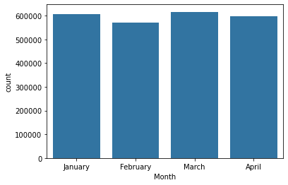

```python
base_color = sb.color_palette()[0]
g = sb.countplot(data=df_2008, x='Month', color=base_color)
xticks = ['January', 'February', 'March', 'April']
g.set(xticklabels=xticks);
```

> January and March appears to have the highest number of flights overally which is likely because they both have 31 days

```python
def days_distribution(df):
    """
    Function takes in a dataframe and prints 2 visualisations side by side

    Args:
        df = dataframe
    Returns:
        2 Bar charts side by side, of DayofMonth distribution and DayOfWeek distribution,
          which are variables of the original flight data
    """

    base_color = sb.color_palette()[0]
    plt.figure(figsize=[20, 5])
    plt.subplot(1, 2, 1)
    sb.countplot(data=df, x='DayofMonth', color=base_color)
    plt.title('On-time flights per DayofMonth')
    plt.ylabel('Number of Flights');

    plt.subplot(1, 2, 2)
    p = sb.countplot(data=df, x='DayOfWeek', color=base_color)
    plt.title('On-time flights per DayOfWeek')
    plt.ylabel('Number of Flights');
    days = ['Monday', 'Tuesday', 'Wednesday', 'Thursday', 'Friday', 'Saturday', 'Sunday']
    p.set(xticklabels = days);
```

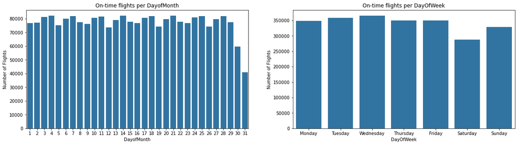

```python
days_distribution(df_2008)
```

> 31 January and 31 March had the lowest number of flights and overally Saturdays recorded the fewest flights followed by Sundays

```python
def overall_carriers(df):
    """
    Function displays the overall number of flights for each airline of the given dataframe,
     using the 'UniqueCarrier' variable

    Args:
        df = dataframe
    Returns:
        An ordered Bar chart of airlines with their total number of flights
    """

    plt.figure(figsize=(22, 10))
    base_color = sb.color_palette()[0]
    carriers = df['UniqueCarrier'].value_counts()
    sb.barplot(carriers.index, carriers.values, color='blue')
    bins = df.shape[0]
    plt.xlabel('Airline Code')
    plt.ylabel('Flights')
    plt.title('Overall number of flights per Airline',fontsize=18)    # Default title
```

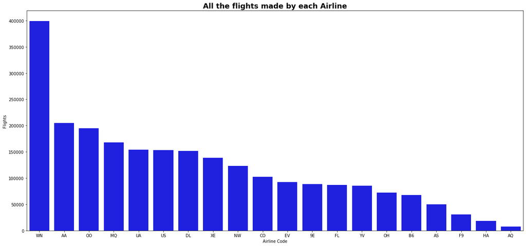

```python
overall_carriers(df_2008)
plt.title('All the flights made by each Airline', fontsize=18, fontweight='semibold');
```

> Airline with airline code WN made the highest number of flights altogether from January to April.

**Next up, I will be looking at the delays, causes for the delays and how they were distributed**

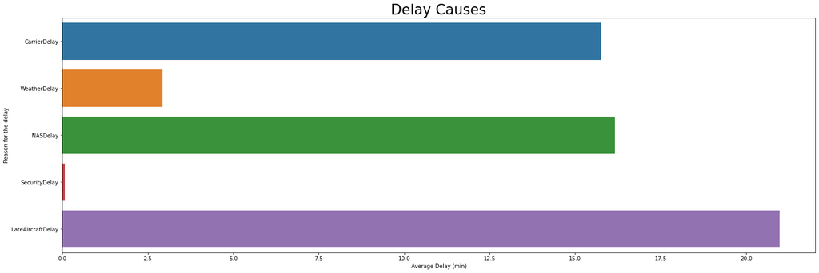

```python
plt.figure(figsize=(25, 8))
delays = [delayed_flights[i].mean() for i in ['CarrierDelay', 'WeatherDelay', 'NASDelay', 'SecurityDelay', 'LateAircraftDelay']]
sb.barplot(delays, ['CarrierDelay', 'WeatherDelay', 'NASDelay', 'SecurityDelay', 'LateAircraftDelay'])
plt.xlabel('Average Delay (min)')
plt.ylabel('Reason for the delay')
plt.title('Delay Causes', fontsize=26);

# https://www.statology.org/seaborn-font-size/
```

> Most delays were as a result of Late Aircraft Delay while the least delays were due to Security Delays

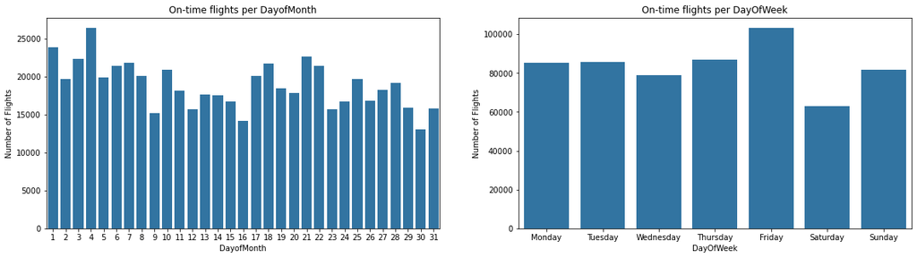

```python
days_distribution(delayed_flights)
```

> Most delays were also observed on Fridays and also on the 4th day of the month

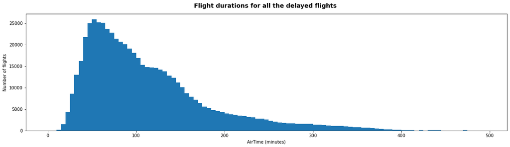

```python
plt.figure(figsize=[20, 5])
bin_edges = np.arange(0, 500, 5)

plt.hist(data=delayed_flights, x='AirTime', bins=bin_edges)
plt.title("Flight durations for all the delayed flights ", y=1.03, fontsize=14, fontweight='semibold')
plt.ylabel('Number of flights');
plt.xlabel('AirTime (minutes)');
```

> It seems like the highest number of delays was recorded from flights with a flight duration of about 50 minutes and generally the longer the flight durations were, the smaller the recorded number of delays was. Very short and very long flights experienced the least delays.

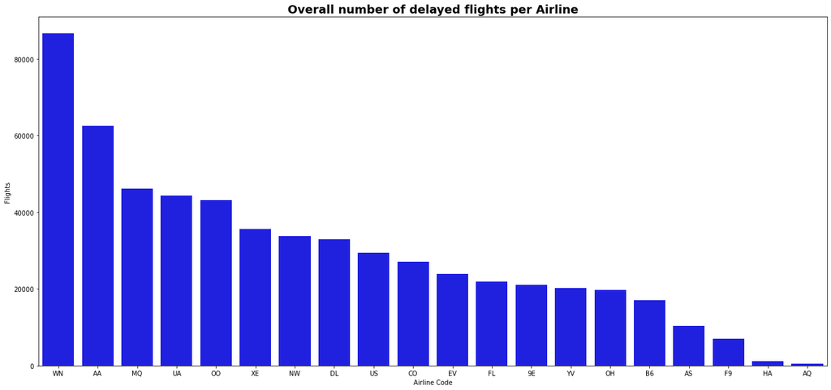

```python
overall_carriers(delayed_flights)
plt.title('Overall number of delayed flights per Airline', fontsize=18, fontweight='semibold');
```

> Airlines with airline code WN and AA experienced the most number of delays from January to April while airline code AQ had the smallest recorded number of delays. This distribution is consistent with the overall number of flights made by each airline as seen before in that the bigger the number of flights made, the bigger the recorded number of delays.

**Next, I will be looking at the distribution of flights that were on-time to see how their distributions compare with delayed flights and all the overall flights combined.**

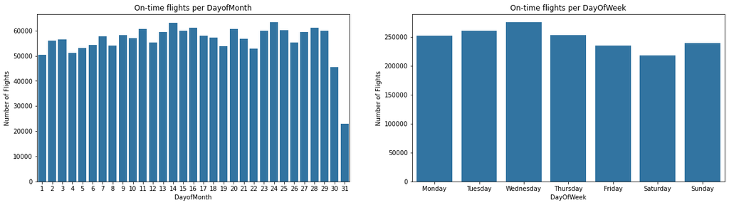

```python
days_distribution(on_time_flights)
```

> Most flights were highly on time during the mid of the months and also from 23rd to the 29th days of the months. Wednesdays also recorded the highest number of on-time flights, followed by Tuesdays and Thursdays.

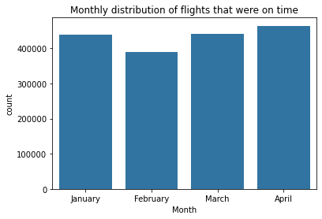

```python
base_color = sb.color_palette()[0]
g = sb.countplot(data=on_time_flights, x='Month', color=base_color)
xticks = ['January', 'February', 'March', 'April']
g.set(xticklabels=xticks)
plt.title('Monthly distribution of flights that were on time');
```

> April recorded the highest number of on-time flights, followed by January and March.

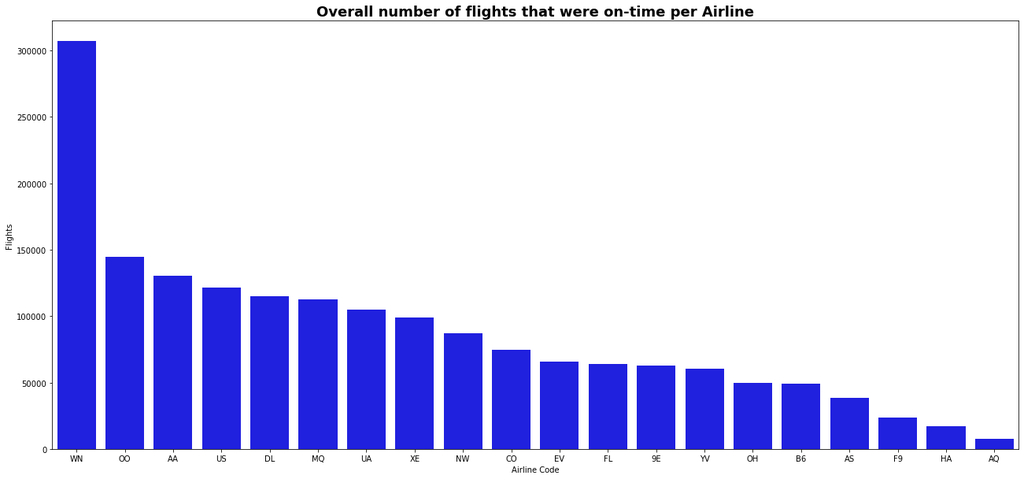

```python
overall_carriers(on_time_flights)
plt.title('Overall number of flights that were on-time per Airline', fontsize=18, fontweight='semibold');
```

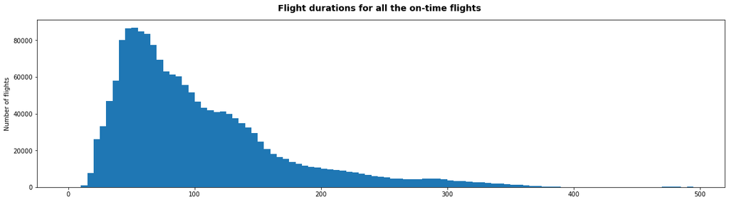

```python
plt.figure(figsize=[20, 5])
bin_edges = np.arange(0, 500, 5)

plt.hist(data=on_time_flights, x='AirTime', bins=bin_edges)
plt.title("Flight durations for all the on-time flights ", y=1.03, fontsize=14, fontweight='semibold')
plt.ylabel('Number of flights');
```

### Discuss the distribution(s) of your variable(s) of interest. Were there any unusual points? Did you need to perform any transformations?

> The delays were all almost always consistent and proportional to the overal number of flights made by each airline. I did not need to perfom any transformations to the data.

### Of the features you investigated, were there any unusual distributions? Did you perform any operations on the data to tidy, adjust, or change the form of the data? If so, why did you do this?

> I found it interesting that the 31st day of the month had a very low number of flights and a higher number of delays at the same time. However the distributions were not very unusual.

## Bivariate Exploration

To start off, I will look at the distributions of Delayed flights and how they compare to the overall distributions of all flights.

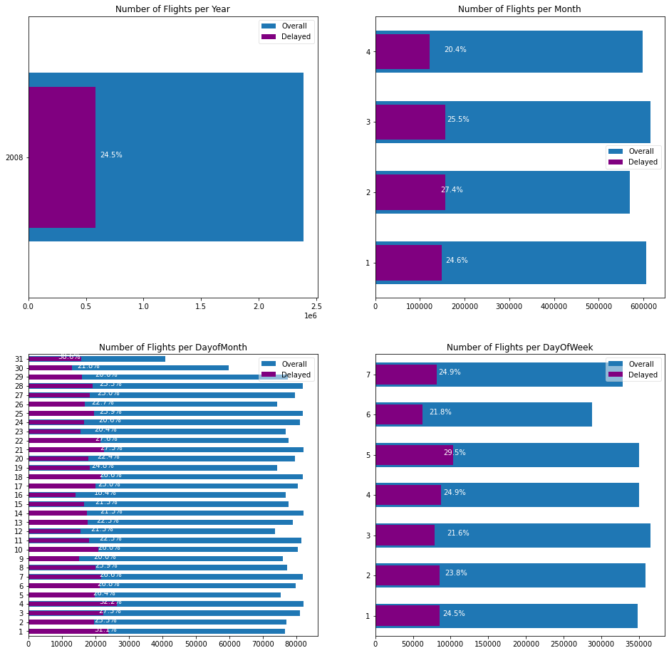

```python
plt.figure(figsize=(16, 16))
n_points = df_2008.shape[0]
for i, j in enumerate(['Year', 'Month', 'DayofMonth', 'DayOfWeek']):
    plt.subplot(2, 2, i+1)

    gen_counts = df_2008[j].value_counts()
    delayed_gen_counts = delayed_flights[j].value_counts()

    gen_counts.sort_index().plot.barh(label='Overall', width=.6)
    delayed_gen_counts.sort_index().plot.barh(label='Delayed', color='purple')

    locs, labels = plt.yticks()
    for loc, label in zip(locs, labels):
        count = gen_counts[int(label.get_text())]
        delayed_count = delayed_gen_counts[int(label.get_text())]
        pct = f'{100*delayed_count/count:0.1f}%'
        plt.text(0.30*count, loc, pct, ha='center', color='w')

    plt.legend(framealpha=0.5, fancybox=True)
    plt.title(f'Number of Flights per {j}')
```

> February and Fridays had the highest proportion of delays. April and Wednesdays had the lowest delays.

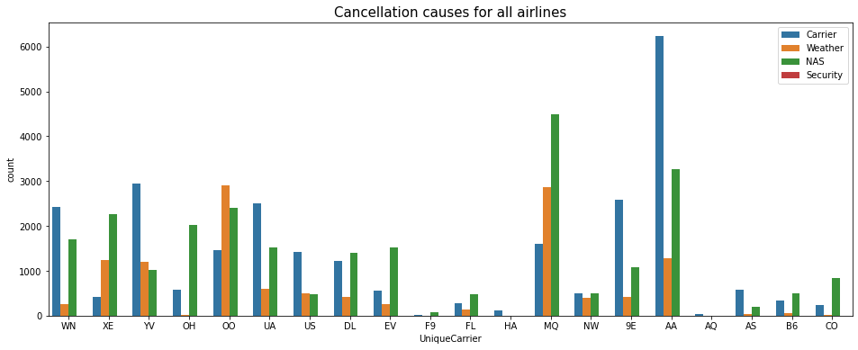

```python
plt.figure(figsize=(16, 6))
sb.countplot(data=df_2008[df_2008['Cancelled'] == 1], x='UniqueCarrier', hue='CancellationCode')
plt.legend(labels=['Carrier', 'Weather', 'NAS', 'Security']);
plt.title('Cancellation causes for all airlines', fontsize=15);
```

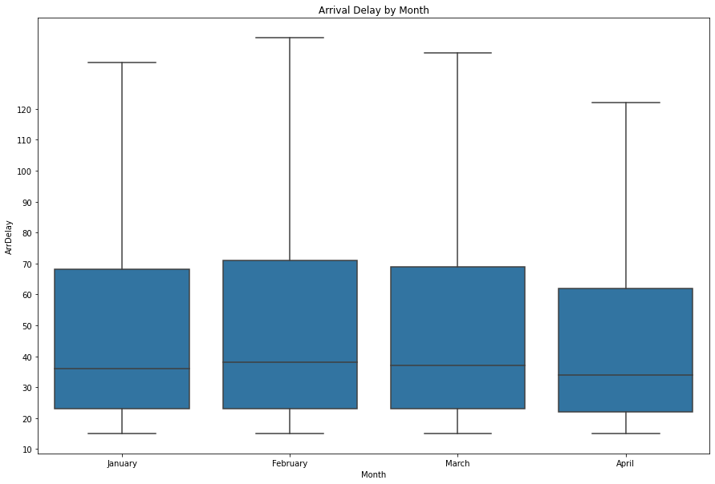

```python
plt.figure(figsize=[15, 10])

f = sb.boxplot(data=delayed_flights, x='Month', y='ArrDelay', showfliers=False, order=[1, 2, 3, 4], color=base_color)
f.set(xticklabels=xticks)
plt.yticks([10, 20, 30, 40, 50, 60, 70, 80, 90, 100, 110, 120])
plt.title('Arrival Delay by Month');
```

> April had the lowest median arrival delay for the whole period, which was a decrease compared to February and March.

## Multivariate Exploration

In this section, I will explore further on other relationships involving delays to get a clearer picture on the best and worst time for flights.

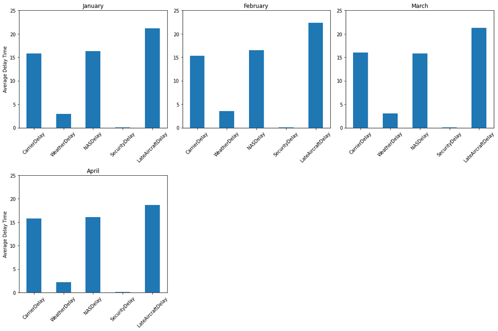

```python
plt.figure(figsize = (15, 10))
for i in np.arange(1, 5):
    plt.subplot(2, 3, i)
    if i in np.arange(1, 5, 3):
        plt.ylabel('Average Delay Time')
    df_2008.query('Month == {}'.format(i))[['CarrierDelay', 'WeatherDelay', 'NASDelay', 'SecurityDelay', 'LateAircraftDelay']].mean().plot(kind = 'bar', color = base_color);
    plt.ylim(0, 25)
    plt.xticks(rotation = 45)
    months = ['January', 'February', 'March', 'April']
    plt.title('{}'.format(months[i-1]))
    plt.tight_layout();
```

> Late aircraft delays were the major causes of delays for every month although they were fewer in April.

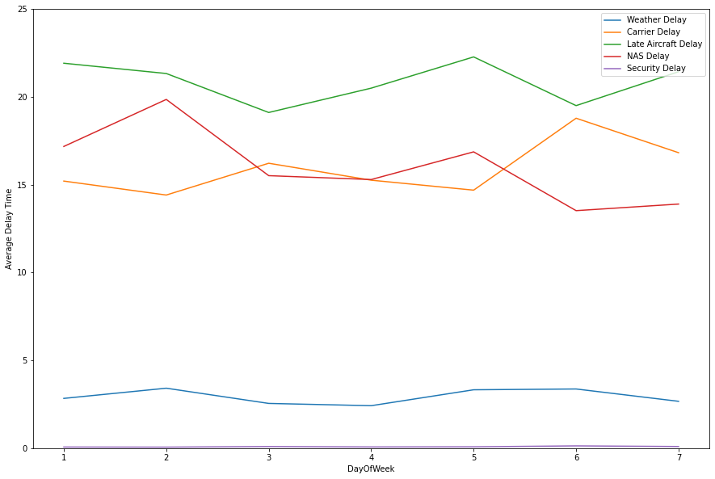

```python
# A line plot showing the average delay time for each day of the week
plt.figure(figsize=(15, 10))
df_2008.groupby(['DayOfWeek'])['WeatherDelay'].mean().plot.line()
df_2008.groupby(['DayOfWeek'])['CarrierDelay'].mean().plot.line()
df_2008.groupby(['DayOfWeek'])['LateAircraftDelay'].mean().plot.line()
df_2008.groupby(['DayOfWeek'])['NASDelay'].mean().plot.line()
df_2008.groupby(['DayOfWeek'])['SecurityDelay'].mean().plot.line()
plt.ylabel('Average Delay Time')
plt.ylim(0, 25)
plt.legend(labels=['Weather Delay', 'Carrier Delay', 'Late Aircraft Delay', 'NAS Delay', 'Security Delay'], loc='upper right');
```

> The highest carrier delays were experienced on Saturdays, late aircraft delays were mostly experienced on Fridays and highest NAS delays were experienced on Tuesdays.

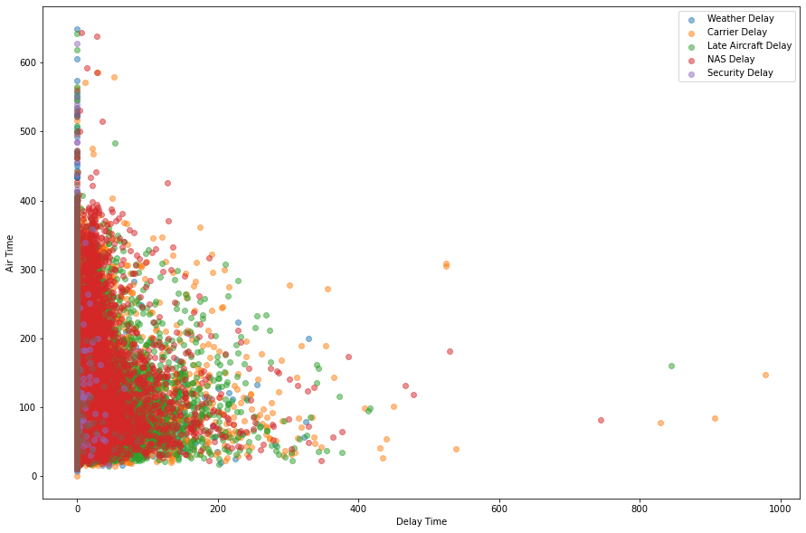

```python
# A scatter plot for Air time vs Delay time
plt.figure(figsize=(15, 10))
plt.scatter(data=delayed_flights.sample(10000),
            x='WeatherDelay', y='AirTime', alpha=1/2)
plt.scatter(data=delayed_flights.sample(10000),
            x='CarrierDelay', y='AirTime', alpha=1/2)
plt.scatter(data=delayed_flights.sample(10000),
            x='LateAircraftDelay', y='AirTime', alpha=1/2)
plt.scatter(data=delayed_flights.sample(10000),
            x='NASDelay', y='AirTime', alpha=1/2)
plt.scatter(data=delayed_flights.sample(10000),
            x='SecurityDelay', y='AirTime', alpha=1/2)
plt.legend(labels=['Weather Delay', 'Carrier Delay',
           'Late Aircraft Delay', 'NAS Delay', 'Security Delay'])
plt.xlabel('Delay Time')
plt.ylabel('Air Time')
plt.scatter(data=delayed_flights.sample(10000),
            x='SecurityDelay', y='AirTime', alpha=1/2)
plt.legend(labels=['Weather Delay', 'Carrier Delay',
           'Late Aircraft Delay', 'NAS Delay', 'Security Delay'])
plt.xlabel('Delay Time')
plt.ylabel('Air Time');
```

> Flights with all air times had experienced security delays although it was only for a few minutes. A higher delay time was common to flights with an air time of less than 300 minutes.

### Talk about some of the relationships you observed in this part of the investigation. Were there features that strengthened each other in terms of looking at your feature(s) of interest?

> I observed the carrier delays were experienced on Saturdays, this was interesting since I had previously observed that Saturdays had recorded the fewest flights in overall among all the days of the week.

### Were there any interesting or surprising interactions between features?

> Most overall delays were experienced on Fridays and they turned out to be mostly due to late aircraft delays.